# Praca domowa 5

Piotr Wawrzyniak

16 listopada 2018

## Wstęp

Jednym z najczęsciej używanych wykresów jest wykres kołowy. Niestety często jest on używany gdy twórca szuka ciekawszej reprezentacji danych - niekoniecznie zastanawiając się jak wpłynie to na percepcje tematu przez czytelnika.

W tej pracy sprawdzę jak zmienia się zrozumienie danych w zależności od typu wykresu. Porównam kolorowy wykres kołowy i standardowy wykres słupkowy w skali szarości.

## Wykres kołowy

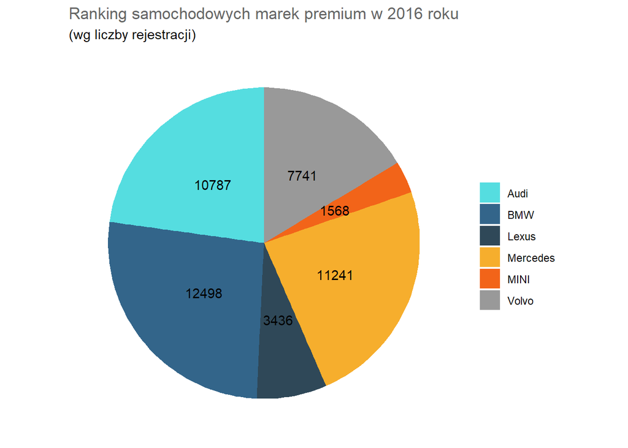

## Wykres słupkowy

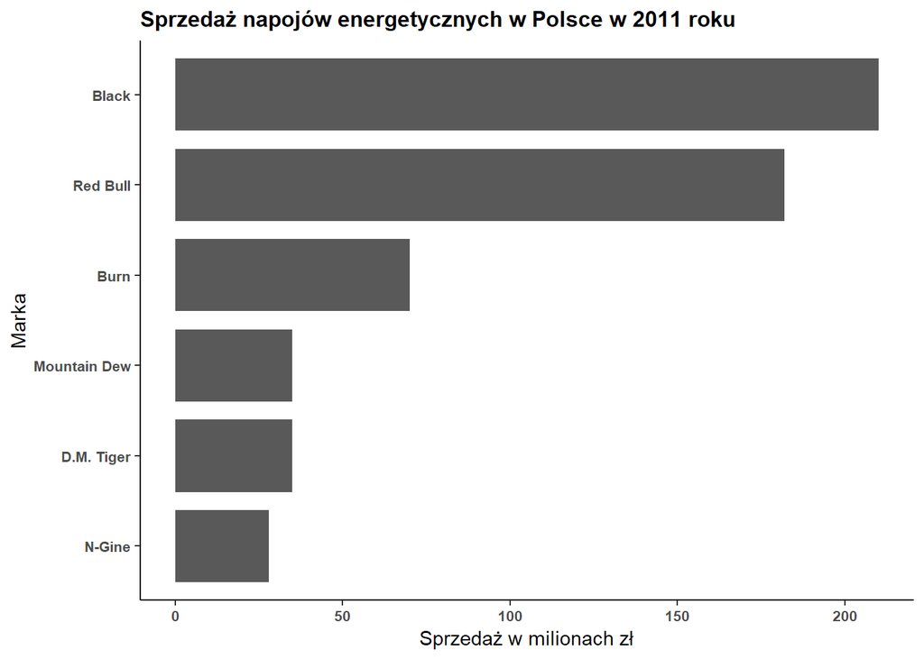

## Wyniki ankiety

W ankiecie wzięło udział 17 osób. Wyniki można znaleźć w pliku “wyniki.csv”, a ankieta dostępna jest pod adresem: https://docs.google.com/forms/d/e/1FAIpQLSebePglCWcvIirqPt7-Gv4DYRZOTdOxvVLUQZ4yNI3nM6Wf4Q/viewform

### Pytanie 1 - maksymalna wartość na wykresie

Jaka marka sprzedała najwięcej samochodów marki premium w 2016 roku

I analogiczne:

Jaka marka sprzedała najwięcej napojów w 2011 roku

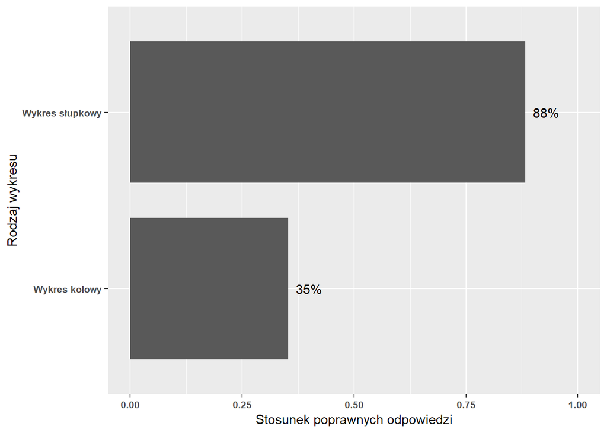

### Pytanie 2 - minimalna wartość na wykresie

Jaka marka sprzedała najmniej samochodów marki premium w 2016 roku

I analogiczne:

Jaka marka sprzedała najmniej napojów w 2011 roku

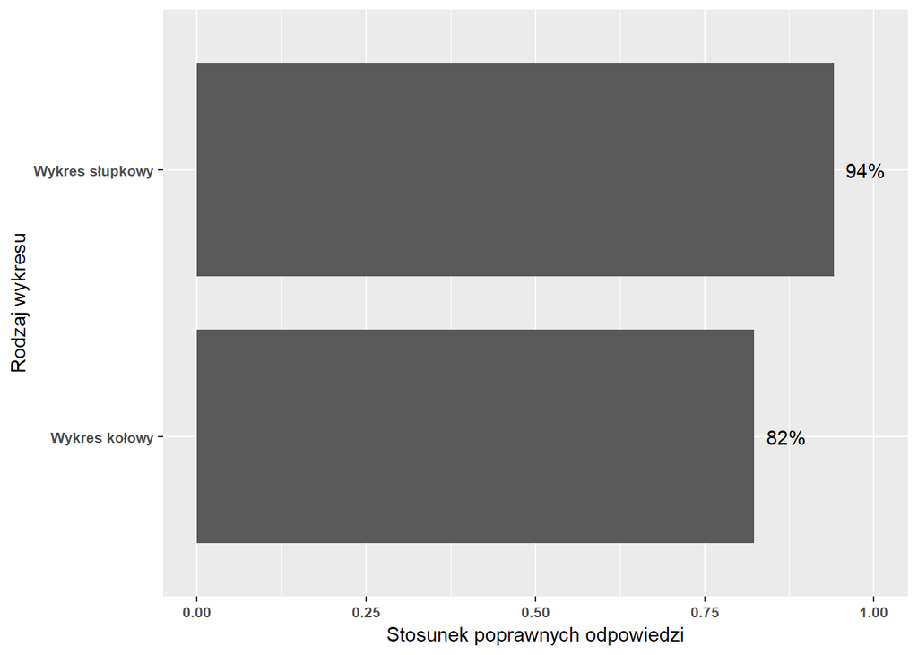

### Pytanie 3 - szacowanie sumy i porównywanie

Czy Audi i Volvo wspólnie sprzedały więcej samochodów niż BMV

I analogiczne:

Czy Burn i D M Tiger sprzedały łącznie więcej napojów niż Red Bull

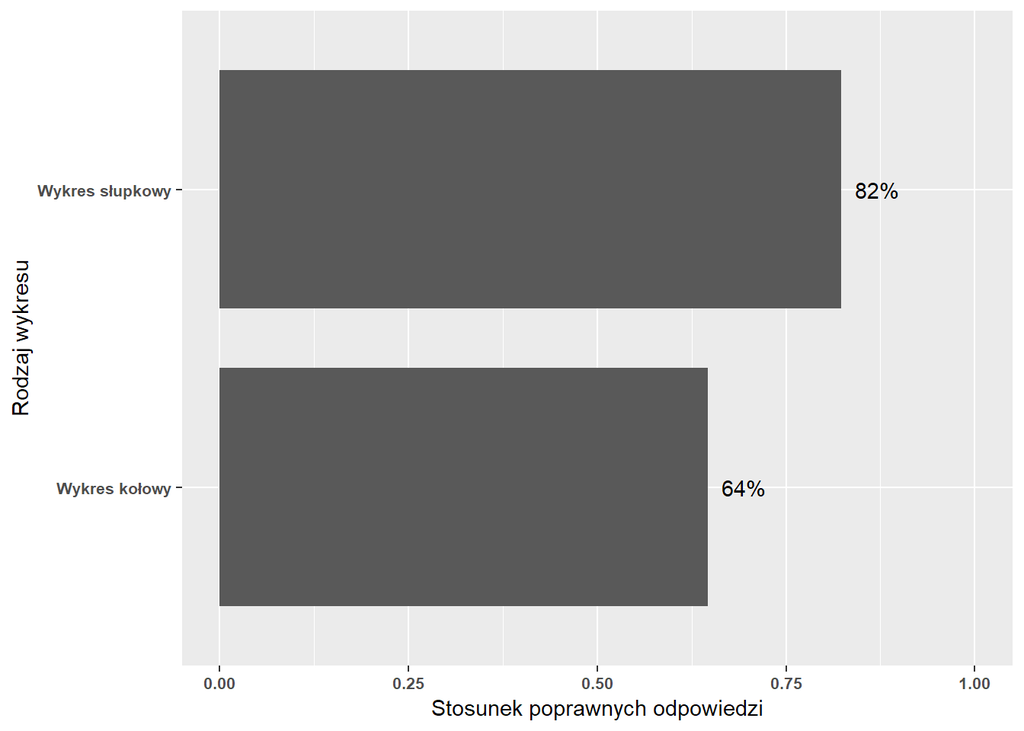

### Pytanie 4 - czy użytkownik zwrócił uwagę na rząd wielkości przedstawianych danych?

Ile samochodów marki premium sprzedał Mercedes

I analogiczne:

Ile wyniosła sprzedaż napoju Burn w zł w Polsce w 2011 roku

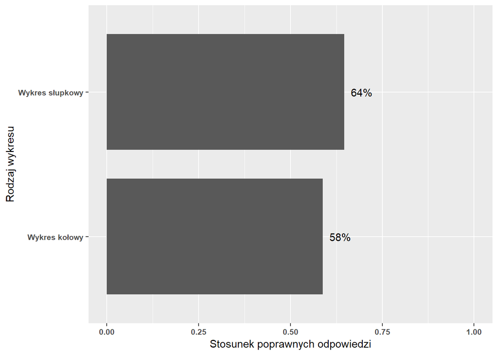

## Wnioski i podsumowanie

Wyniki tego badania są zbieżne z wynikami badaniań prowadzonych kilka i kilkadziesiąt lat temu. Wykresy kołowe mimo, że mniej standardowe niż proste słupki powodują pogorszenie zrozumienia i zapamiętania prezentowanych danych.

Dla każdego pytania okazało się, że czytelnik lepiej rozumie dane, które oglądał na wykresie słupkowym.

Uważam, że dobrym podsumowaniem tego badania będzie następująca animacja znaleziona w sieci:

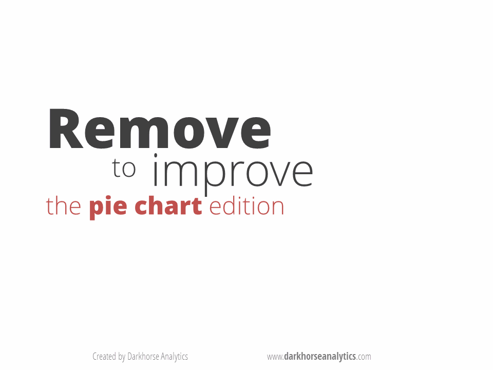